# Ridge Regression using Package glmnet

# **5. 데이터 전처리 II**

```r
# 1. Standardization
preProcValues <- preProcess(UB.trd,
                            method = c("center", "scale"))  # Training Dataset에 대한 평균과 표준편차 계산

UB.trd <- predict(preProcValues, UB.trd)                    # 표준화 for Training Dataset
UB.ted <- predict(preProcValues, UB.ted)                    # 표준화 for Test Dataset

glimpse(UB.trd)                                             # 데이터 구조 확인
```

```
Rows: 1,751
Columns: 13
$ Age                <dbl> -0.05431273, -0.57446728, -0.92123699, -0…
$ Experience         <dbl> -0.12175295, -0.46882565, -0.98943471, -1…
$ Income             <dbl> -0.85867297, -1.35649686, 0.56986515, -0.…
$ ZIP.Code           <dbl> -1.75250883, 0.88354520, 0.53745994, -1.0…
$ Family             <fct> 3, 1, 1, 4, 2, 1, 3, 1, 4, 3, 2, 4, 1, 4,…
$ CCAvg              <dbl> -0.25119120, -0.53150921, 0.42157204, -0.…
$ Education          <fct> 1, 1, 2, 2, 2, 3, 2, 3, 3, 2, 3, 2, 1, 3,…
$ Mortgage           <dbl> -0.5664192, -0.5664192, -0.5664192, -0.56…
$ Personal.Loan      <fct> no, no, no, no, no, no, no, yes, no, no, …
$ Securities.Account <fct> 1, 0, 0, 0, 0, 0, 0, 0, 0, 0, 1, 0, 1, 0,…
$ CD.Account         <fct> 0, 0, 0, 0, 0, 0, 0, 0, 0, 0, 0, 0, 0, 0,…
$ Online             <fct> 0, 0, 0, 0, 1, 0, 1, 0, 0, 1, 0, 1, 0, 0,…
$ CreditCard         <fct> 0, 0, 0, 1, 0, 1, 0, 0, 0, 0, 0, 0, 0, 0,…
```

```r
glimpse(UB.ted)                                             # 데이터 구조 확인
```

```
Rows: 749
Columns: 13
$ Age                <dbl> -1.7881612, -0.7478521, 1.2460737, 0.8126…
$ Experience         <dbl> -1.68358012, -0.64236200, 0.83269699, 0.6…
$ Income             <dbl> -0.53400522, -0.96689556, -1.11840718, -1…
$ ZIP.Code           <dbl> -1.17304370, -0.59585545, 1.07366441, 0.8…
$ Family             <fct> 4, 4, 1, 1, 4, 1, 4, 4, 3, 3, 1, 3, 1, 4,…
$ CCAvg              <dbl> -0.19512759, -0.86789083, -0.25119120, -0…
$ Education          <fct> 1, 2, 3, 2, 2, 3, 3, 3, 3, 2, 1, 2, 1, 2,…
$ Mortgage           <dbl> -0.5664192, 0.9609885, -0.5664192, -0.566…
$ Personal.Loan      <fct> no, no, no, no, no, no, no, no, no, no, n…
$ Securities.Account <fct> 1, 0, 0, 1, 0, 0, 0, 0, 1, 0, 0, 1, 1, 0,…
$ CD.Account         <fct> 0, 0, 0, 0, 0, 0, 0, 0, 0, 0, 0, 1, 0, 0,…
$ Online             <fct> 0, 1, 1, 0, 1, 1, 1, 1, 0, 1, 1, 1, 0, 1,…
$ CreditCard         <fct> 0, 0, 1, 1, 0, 1, 0, 0, 0, 0, 0, 0, 0, 0,…
```

```r
# 2. Convert Factor Var. into Dummy Var.
train.x <- model.matrix(Personal.Loan ~.,                   # Personal.Loan은 Target으로 제외
                        UB.trd)[,-1]                        # [,-1] : 절편 제거

train.x
```

```
             Age  Experience       Income    ZIP.Code Family2 Family3
2    -0.05431273 -0.12175295 -0.858672972 -1.75250883       0       1
3    -0.57446728 -0.46882565 -1.356496863  0.88354520       0       0
4    -0.92123699 -0.98943471  0.569865150  0.53745994       0       0
5    -0.92123699 -1.07620288 -0.620583285 -1.04610783       0       0
7     0.63922667  0.57239246 -0.036181326 -0.82923532       1       0
8     0.37914940  0.31208793 -1.118407176  0.44126189       0       0
9    -0.92123699 -0.90266653  0.158619327 -1.75250883       0       1
10   -1.00792941 -0.98943471  2.301426510 -0.08241975       0       0
11    1.67953578  1.61361058  0.678087735  0.87785301       0       0
12   -1.44139154 -1.33650741 -0.620583285 -1.64549562       0       1
13    0.20576455  0.22531976  0.872888388 -0.03517456       1       0
14    1.15938123  1.00623334 -0.728805870  0.99738903       0       0
15    1.85292063  1.78714693  0.829599354 -0.81215874       0       0
17   -0.66115971 -0.55559383  1.219200660  1.04861876       0       0
```

[output cut: 5241 more lines]

```r
test.x <- model.matrix(Personal.Loan ~.,                    # Personal.Loan은 Target으로 제외
                       UB.ted)[,-1]                         # [,-1] : 절편 제거

test.x
```

```
             Age  Experience       Income     ZIP.Code Family2
1    -1.78816124 -1.68358012 -0.534005217  -1.17304370       0
6    -0.74785214 -0.64236200 -0.966895557  -0.59585545       0
16    1.24607365  0.83269699 -1.118407176   1.07366441       0
20    0.81261153  0.65916064 -1.140051693   0.88354520       0
21    0.89930395  0.91946517 -1.053473625   0.48224568       0
29    0.89930395  0.83269699 -0.555649734   0.78051653       0
35   -1.26800669 -1.33650741 -0.512360700   0.49363006       0
40   -0.66115971 -0.64236200  0.136974810   0.53916759       0
41    0.98599638  1.00623334  0.223552878  -0.28221568       0
47   -0.57446728 -0.55559383 -0.663872319   1.05089564       0
52    1.33276608  1.44007422  1.240845177   0.88354520       0
57    0.81261153  0.83269699 -0.966895557   0.47655348       0
62    0.11907212  0.05178341  1.110978075   0.13616041       0
64   -0.31439001 -0.29528930 -0.901962006   0.77140902       0
```

[output cut: 2235 more lines]

# **6. 모형 훈련**

Package `"glmnet"`에서 제공하는 함수 `glmnet()`을 이용하여 `Ridge Regression`을 수행할 수 있다. 함수 `glmnet()`는 Target이 2개의 클래스를 가질 때 “두 번째 클래스”에 속할 확률을 모델링하며, “두 번째 클래스”란 “Factor” 변환하였을 때 두 번째 수준(Level)을 의미한다. 예를 들어, “a”와 “b” 2개의 클래스를 가진 Target을 “Factor” 변환하였을 때 수준이 “a” “b”라면, 첫 번째 클래스는 “a”, 두 번째 클래스는 “b”가 된다. 함수 `glmnet()`에 대한 자세한 옵션은 [여기](https://www.rdocumentation.org/packages/glmnet/versions/4.1-8/topics/glmnet)를 참고한다.

```r
glmnet(x, y, family, alpha, lambda, ...)
```

- `x` : 예측 변수를 포함하는 행렬
- `y` : Target을 포함하는 변수
- `family` : Target의 분포
  - `"gaussian"` : 수치형인 Target
  - `"binomial"` : 2개의 클래스를 가지는 Target
  - `"multinomial"` : 3개 이상 클래스를 가지는 Target
  - `"poisson"` : Count Data인 Target
- `alpha` : Elasticnet Mixing Parameter
  - `0` : Ridge Regression
  - `1` : Lasso Regression
  - `0 < alpha < 1` : Elastic Net Regression
- `lambda` : Regularization Parameter
  - 직접 값을 지정하면 해당 값에 대한 결과만 보여준다.
  - 값을 지정하지 않으면 100개의 `lambda` 값에 대한 결과를 보여준다.

## **6-1. 람다 값 직접 지정**

```r
ridge.fit <- glmnet(x = train.x,                 # 예측 변수를 포함하는 행렬
                    y = UB.trd$Personal.Loan,    # Target
                    family = "binomial",         # Binary Classification
                    alpha = 0,                   # 0 : Ridge / 1 : Lasso / 0 < alpha < 1 : Elastic Net
                    lambda = 1)

round(coef(ridge.fit), 3)                        # 회귀계수 추정치
```

```
16 x 1 sparse Matrix of class "dgCMatrix"
                        s0
(Intercept)         -2.265
Age                 -0.004
Experience          -0.004
Income               0.138
ZIP.Code             0.002
Family2             -0.040
Family3              0.046
Family4              0.030
CCAvg                0.093
Education2           0.058
Education3           0.058
Mortgage             0.038
Securities.Account1  0.019
CD.Account1          0.380
Online1              0.016
CreditCard1         -0.014
```

`Result!` 데이터 “UB.trd”의 Target “Personal.Loan”은 “no”와 “yes” 2개의 클래스를 가지며, “Factor” 변환하면 알파벳순으로 수준을 부여하기 때문에 “yes”가 두 번째 클래스가 된다. 즉, “yes”에 속할 확률(= 개인 대출 제의를 수락할 확률)을 $p$라고 할 때, 추정된 회귀계수를 이용하여 다음과 같은 모형식을 얻을 수 있다.
$$\begin{align*}
\log{\frac{p}{1-p}} = &-2.265 -0.004 Z_{\text{Age}} -0.004 Z_{\text{Experience}} + 0.138 Z_{\text{Income}} \\
&+0.002 Z_{\text{ZIP.Code}} -0.040 X_{\text{Family2}} + 0.046 X_{\text{Family3}} + 0.030 X_{\text{Family4}} \\
&+ 0.093 Z_{\text{CCAvg}} + 0.058 X_{\text{Education2}} + 0.058 X_{\text{Education3}} + 0.038 Z_{\text{Mortgage}} \\
&+ 0.019 X_{\text{Securities.Account1}} + 0.380 X_{\text{CD.Account1}} + 0.016 X_{\text{Online1}} -0.014 X_{\text{CreditCard1}}
\end{align*}$$
여기서, $Z_{\text{예측 변수}}$는 표준화한 예측 변수, $X_{\text{예측 변수}}$는 더미 변수를 의미한다.

## **6-2. 교차 검증을 통한 최적의 람다 값**

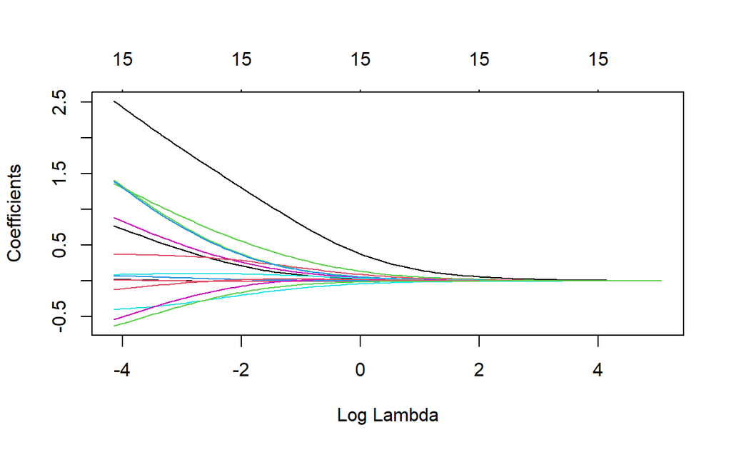

```r
# 100개의 람다 값에 따른 결과
ridge.fit <- glmnet(x = train.x,                 # 예측 변수를 포함하는 행렬
                    y = UB.trd$Personal.Loan,    # Target
                    family = "binomial",         # Binary Classification
                    alpha = 0)                   # 0 : Ridge / 1 : Lasso / 0 < alpha < 1 : Elastic Net

plot(ridge.fit, xvar = "lambda")                 # 람다 값에 따른 회귀계수 추정치 확인
```

`Result!` 100개의 $\lambda$ 값에 대한 회귀계수 추정치의 변화를 보여준다. 해당 그림을 통해 $\lambda$ 값이 클수록 회귀계수 추정치는 작아진다는 것을 알 수 있다.

```r
ridge.fit$lambda                                 # 100개의 람다 값
```

```
  [1] 159.18530945 145.04372529 132.15844050 120.41784889 109.72025908
  [6]  99.97301366  91.09168667  82.99935228  75.62591858  68.90752041
 [11]  62.78596621  57.20823402  52.12601218  47.49528092  43.27593107
 [16]  39.43141663  35.92843825  32.73665482  29.82842063  27.17854595
 [21]  24.76407884  22.56410633  20.55957331  18.73311748  17.06891896
 [26]  15.55256324  14.17091639  12.91201123  11.76494374  10.71977856
 [31]   9.76746298   8.89974849   8.10911936   7.38872755   6.73233336
 [36]   6.13425142   5.58930143   5.09276329   4.64033624   4.22810156
 [41]   3.85248867   3.51024419   3.19840377   2.91426640   2.65537100
 [46]   2.41947516   2.20453566   2.00869078   1.83024423   1.66765038
 [51]   1.51950091   1.38451264   1.26151635   1.14944672   1.04733304
 [56]   0.95429086   0.86951429   0.79226904   0.72188604   0.65775567
 [61]   0.59932247   0.54608031   0.49756804   0.45336547   0.41308973
 [66]   0.37639198   0.34295435   0.31248723   0.28472673   0.25943239
 [71]   0.23638513   0.21538533   0.19625109   0.17881668   0.16293110
 [76]   0.14845675   0.13526826   0.12325140   0.11230209   0.10232548
 [81]   0.09323517   0.08495241   0.07740547   0.07052898   0.06426338
 [86]   0.05855440   0.05335259   0.04861289   0.04429426   0.04035928
 [91]   0.03677387   0.03350698   0.03053031   0.02781808   0.02534680
 [96]   0.02309506   0.02104336   0.01917393   0.01747057   0.01591853
```

```r
coef(ridge.fit)                                  # 100개의 람다 값에 따른 회귀계수 추정치
```

```
16 x 100 sparse Matrix of class "dgCMatrix"

(Intercept)         -2.166511e+00 -2.167074e+00 -2.167129e+00
Age                 -6.393465e-39 -4.351962e-05 -4.775977e-05
Experience          -5.888500e-39 -4.008018e-05 -4.398229e-05
Income               1.608392e-37  1.096704e-03  1.203557e-03
ZIP.Code             1.228136e-39  8.412200e-06  9.234586e-06
Family2             -4.313568e-38 -2.943123e-04 -3.230029e-04
Family3              4.743758e-38  3.237809e-04  3.553374e-04
Family4              2.892734e-38  1.975239e-04  2.167871e-04
CCAvg                1.131406e-37  7.712529e-04  8.463497e-04
Education2           5.765293e-38  3.935973e-04  4.319701e-04
Education3           5.749138e-38  3.925216e-04  4.308034e-04
Mortgage             4.739507e-38  3.230502e-04  3.545050e-04
Securities.Account1  3.247497e-38  2.209800e-04  2.425057e-04
CD.Account1          4.479005e-37  3.054235e-03  3.351708e-03
Online1              2.257208e-38  1.537655e-04  1.687253e-04
CreditCard1         -9.577375e-39 -6.558972e-05 -7.200808e-05

(Intercept)         -2.167189e+00 -2.167256e+00 -2.167328e+00
Age                 -5.240201e-05 -5.749395e-05 -6.307884e-05
Experience          -4.825679e-05 -5.294525e-05 -5.808746e-05
Income               1.320764e-03  1.449370e-03  1.590482e-03
ZIP.Code             1.013865e-05  1.113161e-05  1.222230e-05
Family2             -3.544817e-04 -3.890268e-04 -4.269368e-04
Family3              3.899804e-04  4.280007e-04  4.697274e-04
Family4              2.379334e-04  2.611435e-04  2.866190e-04
CCAvg                9.287407e-04  1.019139e-03  1.118319e-03
Education2           4.740964e-04  5.203320e-04  5.710779e-04
Education3           4.728206e-04  5.189373e-04  5.695539e-04
Mortgage             3.890119e-04  4.268715e-04  4.684084e-04
Securities.Account1  2.660679e-04  2.919107e-04  3.202529e-04
CD.Account1          3.678119e-03  4.036277e-03  4.429262e-03
Online1              1.851370e-04  2.031410e-04  2.228907e-04
CreditCard1         -7.905702e-05 -8.679901e-05 -9.530279e-05

(Intercept)         -2.167408e+00 -2.167496e+00 -2.167593e+00
Age                 -6.920404e-05 -7.592135e-05 -8.328748e-05
Experience          -6.372698e-05 -6.991147e-05 -7.669307e-05
Income               1.745311e-03  1.915186e-03  2.101564e-03
```

[output cut: 507 more lines]

```
Age                  0.016725651  0.01874211  0.02081900  0.02295478
Experience           0.009851477  0.01102482  0.01218323  0.01332046
Income               1.247583693  1.28621140  1.32498290  1.36385965
ZIP.Code             0.066667068  0.06873319  0.07069071  0.07253261
Family2             -0.383023418 -0.38813172 -0.39274571 -0.39687351
Family3              0.787136617  0.81971139  0.85265142  0.88591401
Family4              0.686305308  0.71484818  0.74355832  0.77239564
CCAvg                0.370410630  0.37184384  0.37316120  0.37437932
Education2           1.244310796  1.29987628  1.35616043  1.41308180
Education3           1.220822710  1.27708083  1.33421747  1.39215257
Mortgage             0.091792707  0.09034861  0.08888558  0.08741389
Securities.Account1 -0.461509095 -0.48684754 -0.51248865 -0.53839191
CD.Account1          2.347758347  2.40347204  2.45950307  2.51581815
Online1             -0.094153965 -0.10186883 -0.10967734 -0.11756306
CreditCard1         -0.560589664 -0.58399993 -0.60741360 -0.63079614
```

```r
coef(ridge.fit)[,100]                            # 100번째 람다 값에 대한 회귀계수 추정치
```

```
        (Intercept)                 Age          Experience
        -4.23556904          0.02295478          0.01332046
             Income            ZIP.Code             Family2
         1.36385965          0.07253261         -0.39687351
            Family3             Family4               CCAvg
         0.88591401          0.77239564          0.37437932
         Education2          Education3            Mortgage
         1.41308180          1.39215257          0.08741389
Securities.Account1         CD.Account1             Online1
        -0.53839191          2.51581815         -0.11756306
        CreditCard1
        -0.63079614
```

`Caution!` $\lambda$는 모형이 `Training Dataset`에 과적합 되는 것을 방지하기 위해 사용하는 모수이며, 교차 검증(Cross Validation)을 통해 최적의 값을 찾을 수 있다. 이러한 방법은 package `"glmnet"`에서 제공하는 함수 `cv.glmnet()`을 통해 수행할 수 있으며, 함수에 대한 자세한 옵션은 [여기](https://www.rdocumentation.org/packages/glmnet/versions/4.1-8/topics/cv.glmnet)를 참고한다.

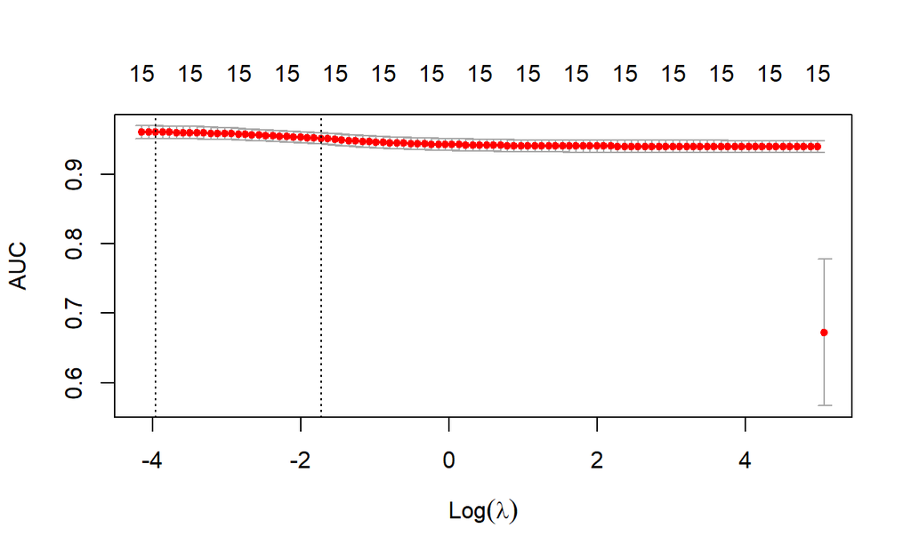

```r
set.seed(200)                                          # Seed 고정 -> 동일한 결과를 출력하기 위해
cv.ridge.fit <- cv.glmnet(x = train.x,                 # 예측 변수를 포함하는 행렬
                          y = UB.trd$Personal.Loan,    # Target
                          family = "binomial",         # Binary Classification
                          alpha = 0,                   # 0 : Ridge / 1 : Lasso / 0 < alpha < 1 : Elastic Net
                          nfolds = 5,                  # 5-Fold Cross Validation
                          type.measure = "auc")        # AUC에 기반하여 최적의 람다 값 찾기
plot(cv.ridge.fit)                                     # Plot
```

`Result!` 100개의 $\lambda$ 값에 대한 AUC의 변화를 보여준다.  
`Caution!` 만약 $\lambda$ 값에 대해 직접 후보 값을 지정하고 싶으면 함수 `cv.glmnet()`의 옵션 `lambda = 후보 값`을 이용하면 된다.

```r
cv.ridge.fit$lambda.min                                   # 최적의 람다 값
```

```
[1] 0.01917393
```

```r
max(cv.ridge.fit$cvm)                                     # 최적의 람다 값에 대한 AUC
```

```
[1] 0.9600085
```

```r
round(coef(cv.ridge.fit, s = cv.ridge.fit$lambda.min), 3) # 최적의 람다 값에 대한 회귀계수 추정치
```

```
16 x 1 sparse Matrix of class "dgCMatrix"
                        s1
(Intercept)         -4.081
Age                  0.019
Experience           0.011
Income               1.286
ZIP.Code             0.069
Family2             -0.388
Family3              0.820
Family4              0.715
CCAvg                0.372
Education2           1.300
Education3           1.277
Mortgage             0.090
Securities.Account1 -0.487
CD.Account1          2.403
Online1             -0.102
CreditCard1         -0.584
```

`Result!` 최적의 $\lambda$ 값에 대해 추정된 회귀계수를 이용하여 다음과 같은 모형식을 얻을 수 있다.
$$\begin{align*}
\log{\frac{p}{1-p}} = &-4.081 + 0.019 Z_{\text{Age}} + 0.011 Z_{\text{Experience}} + 1.286 Z_{\text{Income}} \\
&+0.069 Z_{\text{ZIP.Code}}-0.388 X_{\text{Family2}} + 0.820 X_{\text{Family3}} + 0.715 X_{\text{Family4}} \\
&+ 0.372 Z_{\text{CCAvg}} + 1.300 X_{\text{Education2}} + 1.277 X_{\text{Education3}} + 0.090 Z_{\text{Mortgage}} \\
&-0.487 X_{\text{Securities.Account1}} + 2.403 X_{\text{CD.Account1}} -0.102 X_{\text{Online1}} -0.584 X_{\text{CreditCard1}}
\end{align*}$$

# **7. 모형 평가**

`Caution!` 모형 평가를 위해 `Test Dataset`에 대한 `예측 class/확률` 이 필요하며, 함수 `predict()`를 이용하여 생성한다.

```r
# 예측 class 생성
test.ridge.class <- predict(cv.ridge.fit,
                            newx = test.x,             # Test Dataset including Only 예측 변수
                            s = "lambda.min",          # 최적의 람다 값 기반
                            type = "class")            # 예측 class 생성


test.ridge.class %>%
  as_tibble
```

```
# A tibble: 749 × 1
   lambda.min
   <chr>
 1 no
 2 no
 3 no
 4 no
 5 no
 6 no
 7 no
 8 no
 9 no
10 no
# ℹ 739 more rows
```

## **7-1. ConfusionMatrix**

```r
CM   <- caret::confusionMatrix(as.factor(test.ridge.class), UB.ted$Personal.Loan,
                               positive = "yes")       # confusionMatrix(예측 class, 실제 class, positive = "관심 class")
CM
```

```
Confusion Matrix and Statistics

          Reference
Prediction  no yes
       no  669  39
       yes   4  37

               Accuracy : 0.9426
                 95% CI : (0.9234, 0.9581)
    No Information Rate : 0.8985
    P-Value [Acc > NIR] : 1.196e-05

                  Kappa : 0.6043

 Mcnemar's Test P-Value : 2.161e-07

            Sensitivity : 0.48684
            Specificity : 0.99406
         Pos Pred Value : 0.90244
         Neg Pred Value : 0.94492
             Prevalence : 0.10147
         Detection Rate : 0.04940
   Detection Prevalence : 0.05474
      Balanced Accuracy : 0.74045

       'Positive' Class : yes
```

## **7-2. ROC 곡선**

```r
# 예측 확률 생성
test.ridge.prob <- predict(cv.ridge.fit,
                           newx = test.x,              # Test Dataset including Only 예측 변수
                           s = "lambda.min",           # 최적의 람다 값 기반
                           type = "response")          # 예측 확률 생성


test.ridge.prob %>%                                    # "Personal.Loan = yes"에 대한 예측 확률
  as_tibble
```

```
# A tibble: 749 × 1
   lambda.min
        <dbl>
 1    0.00819
 2    0.0239
 3    0.00692
 4    0.00373
 5    0.0257
 6    0.0159
 7    0.0504
 8    0.114
 9    0.0914
10    0.0458
# ℹ 739 more rows
```

```r
ac  <- UB.ted$Personal.Loan                            # Test Dataset의 실제 class
pp  <- as.numeric(test.ridge.prob)                     # 예측 확률을 수치형으로 변환
```

### **1) Package “pROC”**

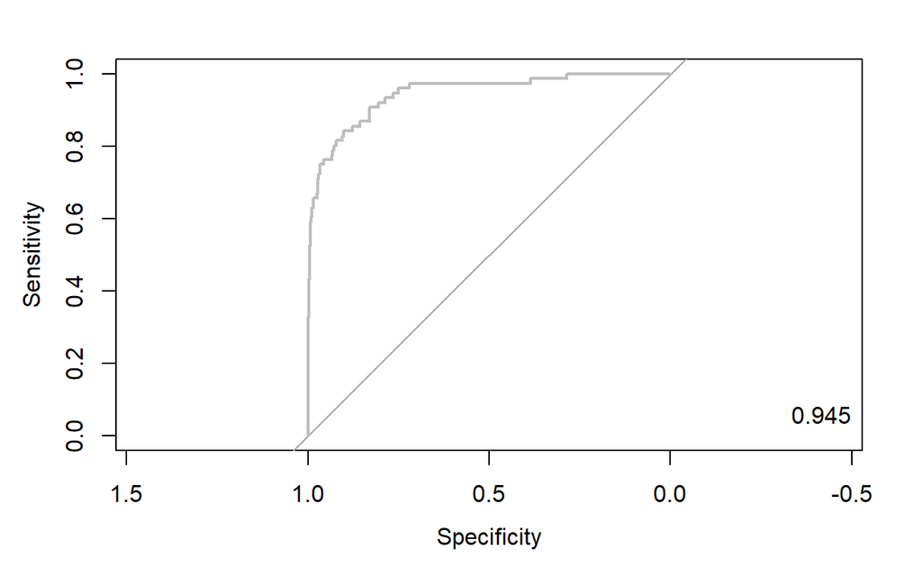

```r
pacman::p_load("pROC")

ridge.roc  <- roc(ac, pp, plot = T, col = "gray")      # roc(실제 class, 예측 확률)
auc        <- round(auc(ridge.roc), 3)
legend("bottomright", legend = auc, bty = "n")
```

`Caution!` Package `"pROC"`를 통해 출력한 ROC 곡선은 다양한 함수를 이용해서 그래프를 수정할 수 있다.

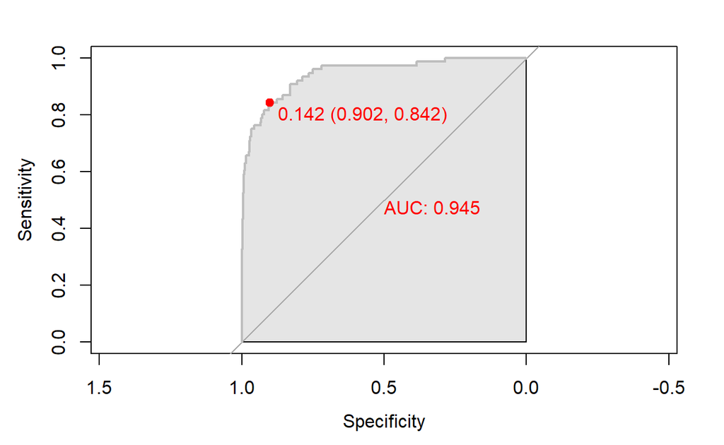

```r
# 함수 plot.roc() 이용
plot.roc(ridge.roc,
         col="gray",                                   # Line Color
         print.auc = TRUE,                             # AUC 출력 여부
         print.auc.col = "red",                        # AUC 글씨 색깔
         print.thres = TRUE,                           # Cutoff Value 출력 여부
         print.thres.pch = 19,                         # Cutoff Value를 표시하는 도형 모양
         print.thres.col = "red",                      # Cutoff Value를 표시하는 도형의 색깔
         auc.polygon = TRUE,                           # 곡선 아래 면적에 대한 여부
         auc.polygon.col = "gray90")                   # 곡선 아래 면적의 색깔
```

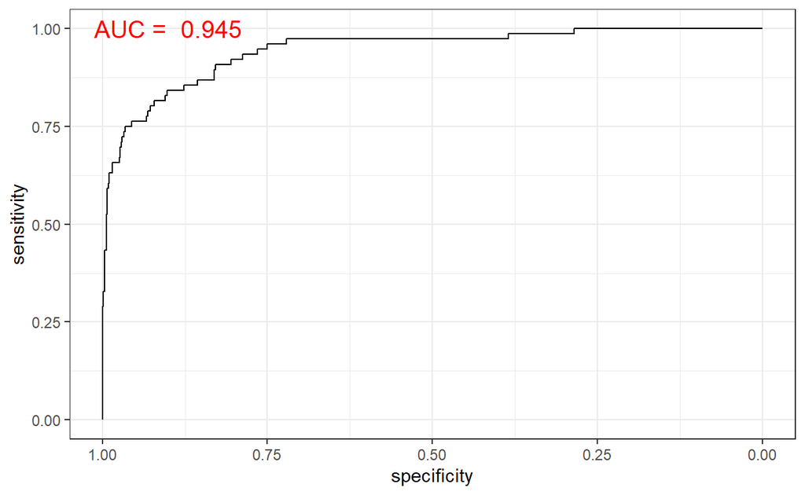

```r
# 함수 ggroc() 이용
ggroc(ridge.roc) +
annotate(geom = "text", x = 0.9, y = 1.0,
label = paste("AUC = ", auc),
size = 5,
color="red") +
theme_bw()
```

### **2) Package “Epi”**

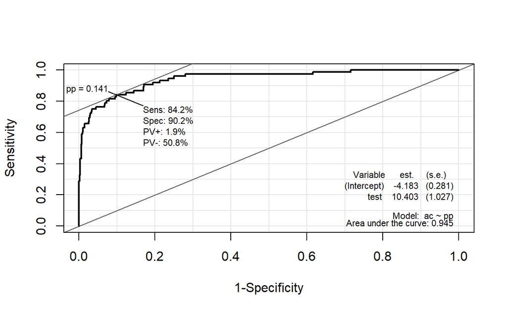

```r
pacman::p_load("Epi")
# install_version("etm", version = "1.1", repos = "http://cran.us.r-project.org")

ROC(pp, ac, plot = "ROC")                              # ROC(예측 확률, 실제 class)
```

### **3) Package “ROCR”**

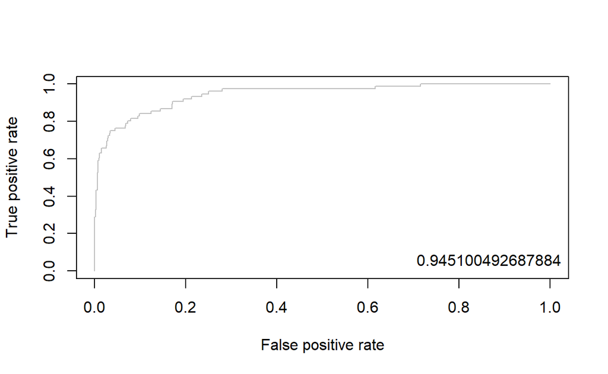

```r
pacman::p_load("ROCR")

ridge.pred <- prediction(pp, ac)                       # prediction(예측 확률, 실제 class)

ridge.perf <- performance(ridge.pred, "tpr", "fpr")    # performance(, "민감도", "1-특이도")
plot(ridge.perf, col = "gray")                         # ROC Curve

perf.auc   <- performance(ridge.pred, "auc")           # AUC
auc        <- attributes(perf.auc)$y.values
legend("bottomright", legend = auc, bty = "n")
```

## **7-3. 향상 차트**

### **1) Package “ROCR”**

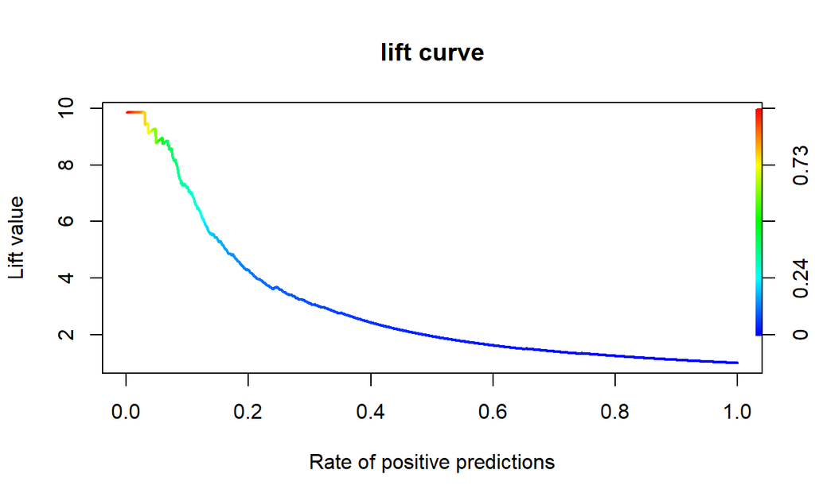

```r
ridge.perf <- performance(ridge.pred, "lift", "rpp")   # Lift Chart
plot(ridge.perf, main = "lift curve",
     colorize = T,                                     # Coloring according to cutoff
     lwd = 2)
```